# Tuberculosis US Report: Proposal for a new vaccine

Saleh Sarwar and Vaidehi Ponkshe

2023-06-28

Matriculation Number

- Saleh Sarwar: 22210364
- Vaidehi Ponkshe: 22201071

Email

- muhammad.sarwar@stud.th-deg.de
- vaidehi.ponkshe@stud.th-deg.de

# Introduction

Tuberculosis (TB) is one of the world’s leading infectious disease killers. According to World Health Organisation (WHO), TB was responsible for death of total 1.6 million people in 2021. And an estimated 10.6 million people fell ill worldwide. It is an infectious disease that most often affects the lungs and is caused by a type of bacteria. It spreads through the air when infected people cough, sneeze or spit. This report is generated to understand and analyse the trends in TB infections across the US and proposal for developing a new vaccine to combat the current TB crisis

# Problem Definition

# Objectives

- To perform long term trend analysis on both country as well as state level of US.
- To perform demographic analysis
- To perform drug resistance analysis

# Methods

- Methods from descriptive statistics: Descriptive Statistics
- Statistics for scientific work: Literate Statistical Analysis
- Advanced-Data visualization techniques: ggplot2, gganimate, highcharter

```r
library(tidyverse)
library(ggthemes)
library(knitr)
library(gganimate)
library(kableExtra)
library(highcharter)
library(viridis)
library(DT)
```

# Data for the analysis

The data used to carry out this analysis is mainly taken from Online [Tuberculosis Information System](https://wonder.cdc.gov/TB-v2021.html) (also known as “CDC Wonder”) on the Centers for Disease Control and Prevention . Additionally, [Project Tycho](https://healthdata.gov/dataset/Project-Tycho-Level-2-Data/8ihh-ztee/data) data was used for seasonality analysis.

The datasets have been loaded below to carry out the analysis.

```r
# Import all datasets used in the report

# Data for long term trend
df_cases_US <- read.csv("tb/tb_cases_inci_rate_1953_2021.csv")

# Data for seasonality analysis
df_seasonlity <- read.csv("ProjectTycho_Level2_v1.1.0.csv")

# Data for state longterm analysis
df_state <- read.delim("tb/OTIS TB Data 1993-2021.txt", sep = "\t")

# Data for gender analysis
df_gender <- read.delim("tb/TB_gender_1993_2021.txt", sep = "\t")

# Data for race/ethnicity related analysis
df_tb_race <- read.delim("tb/TB_US_race_1993-2021.txt", sep = "\t")

# Data for age group analysis
df_age <- read.csv("tb/TB_age_group_1993-2021.csv")


# Data for drug resistance analysis
df_drug_resi <- read.csv("tb/TB_drug_resistance_US.csv")
```

# Seasonality analysis

Seasonality Analysis is carried out to understand the trend of seasonal variation and disease transmission which can be used to develop targeted treatment strategies.

The data for seasonality analysis is given in the table below

```r
dt_seasonlity <- datatable(df_seasonlity %>% head())
```

|  | epi_week | country | state | loc | loc_type | disease | event | number | from_date | to_date | url |
| --- | --- | --- | --- | --- | --- | --- | --- | --- | --- | --- | --- |
| 1 | 188824 | US | PA | PHILADELPHIA | CITY | TYPHOID FEVER [ENTERIC FEVER] | DEATHS | 14 | 1888-06-10 | 1888-06-16 | http://www.ncbi.nlm.nih.gov/pmc/articles/PMC2084171 |
| 2 | 188824 | US | PA | PHILADELPHIA | CITY | SCARLET FEVER | DEATHS | 4 | 1888-06-10 | 1888-06-16 | http://www.ncbi.nlm.nih.gov/pmc/articles/PMC2084171 |
| 3 | 188824 | US | PA | PHILADELPHIA | CITY | DIPHTHERIA | DEATHS | 4 | 1888-06-10 | 1888-06-16 | http://www.ncbi.nlm.nih.gov/pmc/articles/PMC2084171 |
| 4 | 188826 | US | PA | PHILADELPHIA | CITY | TYPHOID FEVER [ENTERIC FEVER] | DEATHS | 12 | 1888-06-24 | 1888-06-30 | http://www.ncbi.nlm.nih.gov/pmc/articles/PMC2084171 |
| 5 | 188826 | US | PA | PHILADELPHIA | CITY | SCARLET FEVER | DEATHS | 5 | 1888-06-24 | 1888-06-30 | http://www.ncbi.nlm.nih.gov/pmc/articles/PMC2084171 |
| 6 | 188826 | US | PA | PHILADELPHIA | CITY | DIPHTHERIA | DEATHS | 7 | 1888-06-24 | 1888-06-30 | http://www.ncbi.nlm.nih.gov/pmc/articles/PMC2084171 |

The data requires preprocessing of generating the year and month columns, converting the columns to right data type and then subsetting the data for tuberculosis is performed as can be seen in the code below (Press Show Code).

```r
# Separating the year and week columns
year <-as.character(df_seasonlity$epi_week)
year <- substr(year, 1, 4)
df_seasonlity$year <- as.integer(year)
week <- as.character(df_seasonlity$epi_week)
week <- substr(week, 5, 6)
df_seasonlity$week <- as.integer(week)

# Convert the column type to integer
df_seasonlity$month <- as.integer(format(as.Date(df_seasonlity$from_date), "%m"))

# Subsetting data for tuberculosis
df_state_tuberculosis <- df_seasonlity %>%
  filter(disease == "TUBERCULOSIS [PHTHISIS PULMONALIS]" & loc_type == "STATE") %>%
  select(year, month, week, loc, disease, event, number, from_date, to_date)
```

To visualize the data for this analysis Line Graph is used. Line graphs are usually used to represent changes over time.

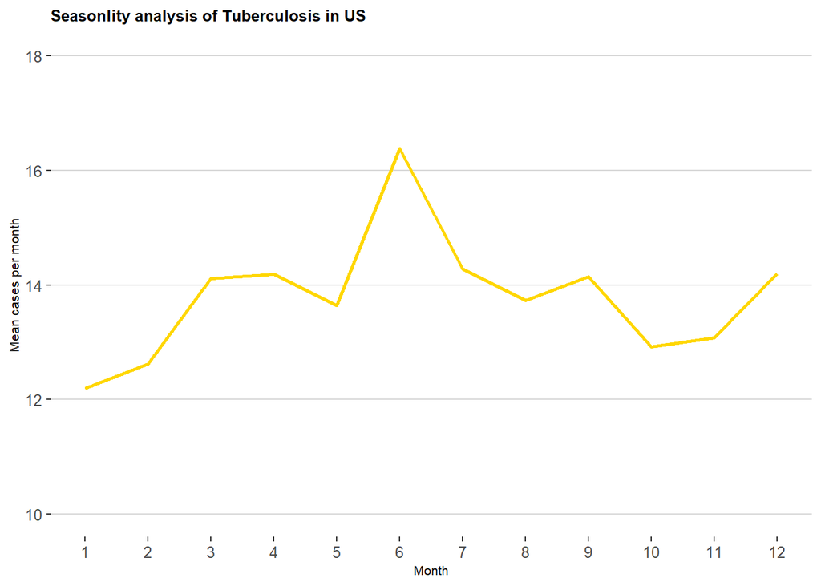

```r
# Make a line chart for seasonlity analysis
line_chart_seasonlity <- df_state_tuberculosis %>%
  select(month, number) %>%
  group_by(month) %>%
  summarise(month_mean = mean(number)) %>%
  ggplot(aes(month, month_mean)) +
  geom_line(color = "gold", linewidth=1) +
  scale_x_continuous(breaks = seq(1,12, 1)) +
  ylim(10,18) +
  theme(title = element_text(size = 8),
        plot.title = element_text(face = "bold")) +
  labs(x = "Month",
      y = "Mean cases per month",
      title = "Seasonlity analysis of Tuberculosis in US") +
  theme_hc()
```

**Observations**

- A peak is observed around the 6th month indicating that Tuberculosis is a seasonal disease with maximum infections developing in June (Summer).

**Insights**

- Seasonality of tuberculosis disease may indicate the presence of season-specific risk factors that could potentially be controlled if they were better understood.

# Long-term Trend analysis:

The overall trend of a disease through out the years can tell a story about how the disease has emerged/declined and the impact of human interventions on it.For this reason, Long-term trend analysis for Tuberculosis from 1953-2021 was performed for incidence and mortality rate.

The dataset used for the analysis is in the table below.

```r
# Display the table

dt_cases_us <- df_cases_US %>%
  datatable()
```

|  | Year | No.Cases | Cases.Rate | Cases_percent_change | Cases_Rate_percent_change | X | No.Deaths | Deaths.rate | Deaths_percent_change | Deaths_rate_percent_change |
| --- | --- | --- | --- | --- | --- | --- | --- | --- | --- | --- |
| 1 | 2021 | 7,882 | 2.4 | 9.9 | 9.8 |  | –– | –– | –– | –– |
| 2 | 2020 | 7,171 | 2.2 | -19.4 | -20.2 |  | 600 | 0.2 | 14.1 | 13 |
| 3 | 2019 | 8,898 | 2.7 | -1.1 | -1.6 |  | 526 | 0.2 | -3 | -3.4 |
| 4 | 2018 | 8,998 | 2.8 | -0.8 | -1.3 |  | 542 | 0.2 | 5.2 | 4.7 |
| 5 | 2017 | 9,069 | 2.8 | -1.9 | -2.5 |  | 515 | 0.2 | -2.5 | -3.1 |
| 6 | 2016 | 9,240 | 2.9 | -3.1 | -3.8 |  | 528 | 0.2 | 12.3 | 11.5 |
| 7 | 2015 | 9,538 | 3 | 1.7 | 0.9 |  | 470 | 0.1 | -4.7 | -5.4 |
| 8 | 2014 | 9,382 | 2.9 | -1.6 | -2.4 |  | 493 | 0.2 | -11.2 | -11.8 |
| 9 | 2013 | 9,539 | 3 | -3.9 | -4.5 |  | 555 | 0.2 | 8.8 | 8.1 |
| 10 | 2012 | 9,923 | 3.2 | -5.3 | -6 |  | 510 | 0.2 | -5.4 | -6.1 |

[output cut: 59 more lines]

The data was processed in order to identify the incomplete, irrelevant, or missing parts of the data and then modified according to the necessity (click on “Show Code” to check the data cleaning and subsetting steps).

```r
# Data cleaning and subseting

df_lta_cases_deaths <- df_cases_US %>%
  select(Year, No.Cases, No.Deaths)

names(df_lta_cases_deaths) <- c("year", "number_of_cases", "number_of_deaths")

df_lta_cases_deaths$number_of_cases <-  as.numeric(gsub(",", "", df_lta_cases_deaths$number_of_cases))

# The unavailable data is shown as "--" replacing it with NA to perform analysis later
df_lta_cases_deaths$number_of_deaths <- replace(df_lta_cases_deaths$number_of_deaths, df_lta_cases_deaths$number_of_deaths == "––", NA)

df_lta_cases_deaths$number_of_deaths <- as.numeric(gsub(",", "", df_lta_cases_deaths$number_of_deaths))

df_lta_inci <- df_cases_US %>%
  select(Year, Cases.Rate, Deaths.rate)

names(df_lta_inci) <- c("year", "cases_incidence_rate", "deaths_incidence_rate")

df_lta_inci$deaths_incidence_rate <- as.numeric(replace(df_lta_inci$deaths_incidence_rate,                                              df_lta_inci$deaths_incidence_rate == "––", NA))
```

Next step is to visualize the data for long term trend analysis with the following graphs.

1. Bar Graph - A bar chart is used when you want to show a distribution of data points or perform a comparison of metric values across different subgroups of your data.

(Note: Click on the “Show code” to see the code)

```r
# Bar chart for long term analysis
cases_deaths_bar_chart <- df_lta_cases_deaths %>%
  pivot_longer(!year, names_to = "cases_death", values_to = "count" ) %>%
  ggplot(aes(year, count, fill = cases_death)) +
  geom_bar(stat = "identity") +
  facet_grid(cases_death ~ ., scale = "free_y") +
  scale_x_continuous(breaks = seq(min(df_lta_cases_deaths$year), max(df_lta_cases_deaths$year), 10)) +
  theme_hc() +
  scale_fill_manual(values = c("number_of_cases" = "grey", "number_of_deaths" = "gold"),
                    labels = c("number_of_cases" = "Cases", "number_of_deaths" = "Deaths")) +
  labs(fill = "Metric",
       y = "Total per year") +
  ggtitle("Comparison of total cases and deaths of Tuberculosis in US (1993-2021)") +
  theme(title = element_text(size = 8),
        plot.title = element_text(face = "bold"),
        strip.text = element_blank())
```

2. Line Graph – Line graphs are usually used to represent changes over time.

```r
# Draw line chart for comparision of cases and deaths rate.
cases_deaths_rate_line_chart <- df_lta_inci %>%
  pivot_longer(!year, names_to = "cases_deaths", values_to = "rates") %>%
  ggplot(aes(year, rates, color = cases_deaths)) +
  geom_line(size = 1) +
  theme_hc() +
  facet_grid(cases_deaths ~ ., scale = "free_y")  +
  scale_color_manual(values = c("cases_incidence_rate" = "grey", "deaths_incidence_rate" = "gold"),
                     labels = c("cases_incidence_rate" = "Incidence rate ",
                                "deaths_incidence_rate" = "Mortality rate")) +
  labs(color = "Metric",
       y = "Cases/Deaths per 100000 persons") +
  ggtitle("Comparison of incidence and mortality rate of Tuberculosis in US (1993-2021)") +
  theme(strip.text = element_blank(),
        title = element_text(size =8),
        plot.title = element_text(face = "bold"))
```

## Bar chart for long term trend:

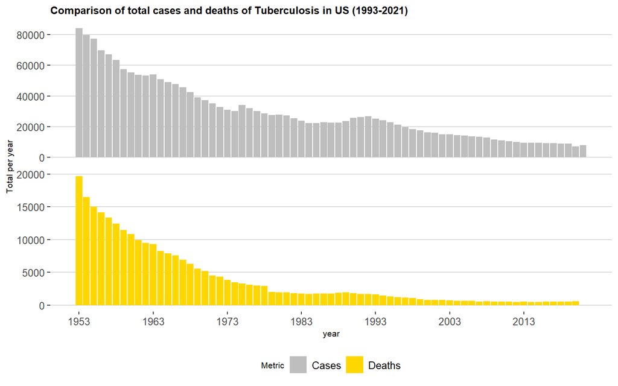

**Observations**

- There is a sharp decrease in number of deaths as compared to the number of cases.
- Number of deaths reduced massively but the mortality rate still persists,albeit at a reduced level.

## Line chart for long term trend

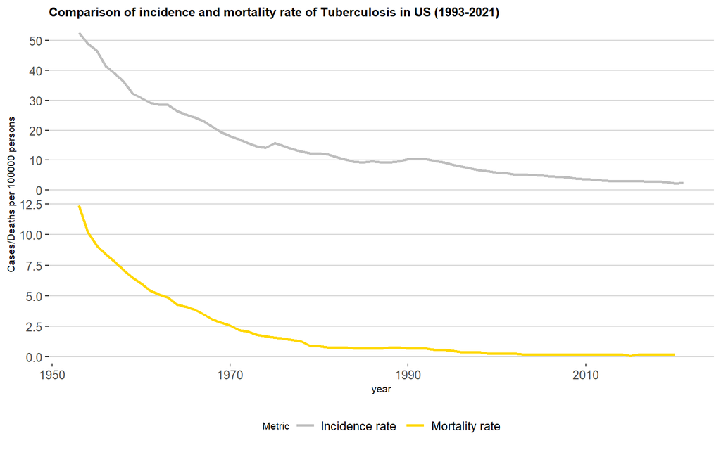

**Observations**

- There is a decrease in both incidence rate and mortality rate over time. - A short peak is observed in the incidence rate around 1970s.

**Insights**

- Sharp decrease in number of deaths indicates a development of treatment for the disease around 1950s. -A short peak in incidence rate around 1970s indicates the first outbreak of drug-resistant TB in the US.
- Decline in the incidence rate suggests a development of a vaccine which is Bacille Calmette-Guérin (BCG) developed in 1921. Since the decrease is not sharp, the efficacy of BCG vaccine could be low.

## State long term analysis:

State level long term incidence rate analysis tells a story about whether a disease is affected by the demographic factor since States usually have different demographics. The idea is that incidence rate would remain constant if the factors do not affect the disease.

```r
# exlude 2021 as no death rate there
df_state_rate <- df_state %>%
  filter(Year != 2021)

# Convert the Rate.per.100.000 to numeric
df_state_rate$Rate.per.100.000 <- as.numeric(df_state_rate$Rate.per.100.000)

n <- 4
rate_max <- max(df_state_rate$Rate.per.100.000, na.rm = TRUE)

# generating specific color pallet
colstops <- data.frame(q = seq(0, rate_max, length.out = n + 1) / rate_max,
                       c = substring(viridis(n + 1, option = "B"), 0, 7)) %>%
  list_parse2()


plot_list_rate <- list()


# Iterate over each year
for (year in unique(df_state_rate$Year)) {
  # Filter the data for the current year
  data_year <- df_state_rate[df_state_rate$Year == year, ]

  # Create the plot for the current year
  plot <- highchart() %>%
    hc_title(text = paste("Tuberculosis rates in US - Year:", year)) %>%
    hc_add_series_map(usgeojson, data_year, name = "Rates by State",
                      value = "Rate.per.100.000", joinBy = c("woename", "State")) %>%
    hc_colorAxis(stops = colstops) %>%
    hc_legend(valueDecimals = 0)  %>%
    hc_add_theme(hc_theme_ggplot2())

  # Add the plot to the list
  plot_list_rate[[as.character(year)]] <- plot
}
```

### 1993

```r
plot_list_rate[["1993"]]
```

[interactive chart not shown]

### 2000

```r
plot_list_rate[["2000"]]
```

[interactive chart not shown]

### 2007

```r
plot_list_rate[["2007"]]
```

[interactive chart not shown]

### 2014

```r
plot_list_rate[["2014"]]
```

[interactive chart not shown]

### 2020

```r
plot_list_rate[["2020"]]
```

[interactive chart not shown]

**Observations**

-Throughout these years, seven states consistently exhibited the highest TB rates. -The incidence rate for these 7 states in 2020 is shown below from highest to lowest.

- Alaska: 7.93
- Hawaii: 6.54
- California: 4.33
- New York: 3.3
- Texas: 3
- New Jersey: 2.76
- Maryland: 2.44

Detailed visualization of the incidence rate of States throughout the years can be depicted through time series animation. ggplot and gganimate was used to create such an animation.

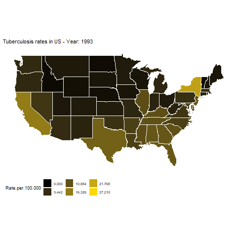

**Observations**

- There is a visible decrease in incidence rates from the year 1993 to 2021 as confirmed by previous graph in long term trend analysis.

**Insights**

- Incidence rate is different across states suggesting that demographics might influence the prevalence of TB. Demographic analysis needs to be performed in order to explore this proposition.

# Demographic Analysis:

Demographic analysis can describe and explain the distribution of TB infections in US population and help with identifying risk factors and assess vulnerable populations. The following demographic analysis were performed within this study.

- Gender Analysis
- Age Specific Analysis
- Race/Ethnicity Analysis

## Gender analysis:

Gender Analysis focuses to understand gender-based differences and thus help in development of targeted treatment strategies. The data used to carry out gender analysis for Tuberculosis in the US from 1993-2021 is given in the table below.

```r
# View the data
dt_gender <- datatable(df_gender)
```

|  | Notes | Year | Year.Code | Sex | Sex.Code | Cases | Percent.of.Total |
| --- | --- | --- | --- | --- | --- | --- | --- |
| 1 |  | 2021 | 2021 | Female | F | 3052 | 0.76% |
| 2 |  | 2021 | 2021 | Male | M | 4827 | 1.20% |
| 3 |  | 2021 | 2021 | Not Reported | NR | 3 | 0.00% |
| 4 |  | 2020 | 2020 | Female | F | 2831 | 0.70% |
| 5 |  | 2020 | 2020 | Male | M | 4340 | 1.08% |
| 6 |  | 2019 | 2019 | Female | F | 3543 | 0.88% |
| 7 |  | 2019 | 2019 | Male | M | 5355 | 1.33% |
| 8 |  | 2018 | 2018 | Female | F | 3476 | 0.86% |
| 9 |  | 2018 | 2018 | Male | M | 5519 | 1.37% |
| 10 |  | 2018 | 2018 | Not Reported | NR | 3 | 0.00% |

[output cut: 90 more lines]

The data had some NAs at the end which was removed and also subsetting was performed.

```r
# subset the relevant column for the analysis
df_gender <- df_gender %>%
  select(Year, Sex, Cases)

# omit the empty rows at the end
df_gender <- na.omit(df_gender)
```

Next, to visualize the data for gender analysis following graphs are used.

1. Stacked bar graphs are used to compare numeric values across two categorical variables. Each bar in a standard bar chart is divided into a number of sub-bars stacked end to end, each one corresponding to a level of the second categorical variable.

```r
stacked_bar_chart_gender <- df_gender %>%
  ggplot(aes(Year, Cases, fill = Sex)) +
  geom_bar(stat = "identity") +
  theme_hc()  +
  scale_fill_manual(values = c("grey", "gold", "red")) +
  scale_x_continuous(breaks = seq(min(df_gender$Year), max(df_gender$Year), 5)) +
  labs(y = "Number of Cases",
       x = "",
       title = "Comparison of cases by gender for Tuberculosis in US(1993-2021)") +
  theme(title = element_text(size =10),
        plot.title = element_text(face = "bold"))
```

2. Line Graph - For this the data was converted to wide format and percentage of total males and females cases were calculated.

```r
# Convert the data to wider for calculating the percentages
df_gender_wide <- df_gender %>%
  select(Year, Sex, Cases) %>%
  pivot_wider(names_from = "Sex", values_from = "Cases")

# Include the total cases column for calculating the percentages
filtered_US_cases <- df_cases_US %>%
  filter(Year >= 1993)

# Including the column and correcting its type
df_gender_wide$total_cases <- filtered_US_cases$No.Cases
df_gender_wide$total_cases <- as.numeric(gsub(",", "",
                                               df_gender_wide$total_cases))

# caluclating percentage of female and male and including it in a column
df_gender_wide <- df_gender_wide %>%
  mutate(percentage_of_female = Female/total_cases * 100, percentage_of_male = Male/total_cases * 100)


line_chart_gender <- df_gender_wide %>%
  ggplot(aes(Year)) +
  geom_line(aes(y = percentage_of_female, color = "Female"), linewidth = 1.2) +
  geom_line(aes(y = percentage_of_male, color = "Male"), linewidth = 1.2) +
  scale_x_continuous(breaks = seq(min(df_gender_wide$Year), max(df_gender_wide$Year), 5)) +
  ylim(0,80) +
  theme_hc() +
  scale_color_manual(values = c("Female" = "grey", "Male" = "gold")) +
  labs(color = "Sex",
       x = "",
       y = "Percentage (%)",
       title = "Comparison of percentage of male and female cases of Tuberculosis in US (1993-2021") +
  theme(title = element_text(size =9, face = "bold"))
```

### Stacked bar chart for gender

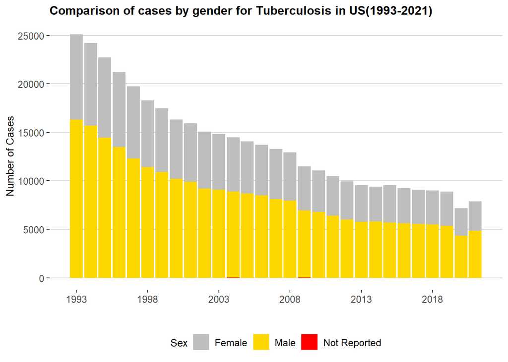

**Observations**

- The number of cases for both males and females decreases over the years.
- Males seem to be affected more than females.

### Line chart for gender

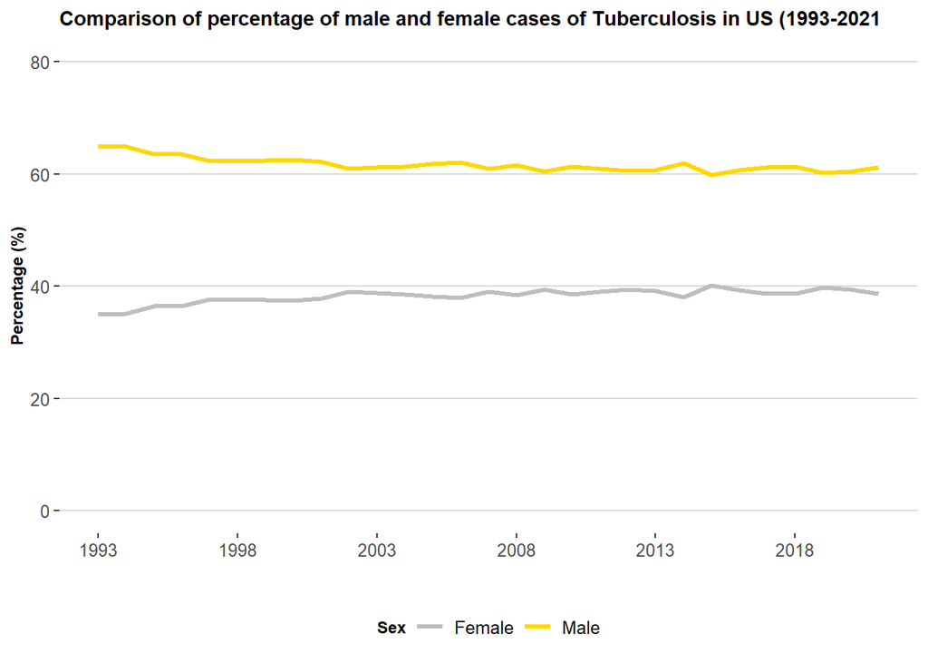

**Observations**

- Males have higher percentage (60%) of TB infections than females.
- The same trend has been continued from 1993 to 2021.

**Insights**

- Tuberculosis affects men and women differently. One of the studies showed smaller B cell follicles in males exhibiting greater susceptibility to TB, and point to a putative role for IL-23 in these dimorphisms.
- Thus, there is a need for the development of individualized vaccination approaches, which will be critical to protect both sexes against Mtb infection in the future.

## Age group Analysis:

Age group analysis helps to understand the disease susceptibility across different age groups and to identify the vulnerable populations. The data used to carry out this analysis is given in the table below.

```r
df_age_rate <- df_age %>%
  select(Year,starts_with("Rate"))

names(df_age_rate) <- c("year","0-4", "5-14", "15-24", "25-44", "45-64", ">64")
dt_age_rate <- datatable(df_age_rate)
```

|  | year | 0-4 | 5-14 | 15-24 | 25-44 | 45-64 | >64 |
| --- | --- | --- | --- | --- | --- | --- | --- |
| 1 | 2021 | 0.8 | 0.4 | 1.6 | 2.5 | 2.9 | 4 |
| 2 | 2020 | 0.9 | 0.4 | 1.6 | 2.4 | 2.6 | 3.4 |
| 3 | 2019 | 1.1 | 0.4 | 2 | 3 | 3.2 | 4.5 |
| 4 | 2018 | 0.9 | 0.5 | 2 | 3.1 | 3.2 | 4.5 |
| 5 | 2017 | 1.1 | 0.5 | 2 | 3.2 | 3.3 | 4.5 |
| 6 | 2016 | 1.1 | 0.4 | 2.1 | 3.3 | 3.4 | 4.6 |
| 7 | 2015 | 1.2 | 0.5 | 2.1 | 3.4 | 3.6 | 4.8 |
| 8 | 2014 | 1.3 | 0.5 | 2.2 | 3.4 | 3.5 | 4.7 |
| 9 | 2013 | 1.5 | 0.5 | 2.2 | 3.6 | 3.6 | 4.9 |
| 10 | 2012 | 1.3 | 0.5 | 2.3 | 3.8 | 3.8 | 5.1 |

[output cut: 19 more lines]

Line graphs for over the years rate and percentage is used to visualize the age group. The data was also preprocessed accordingly

```r
# intuitive name for the columns
age_group <- c("0-4", "5-14", "15-24", "25-44", "45-64", ">64")

# convert the data to long
df_age_rate_long <- df_age_rate %>%
  pivot_longer(cols = all_of(age_group),
               names_to = "age_group",
               values_to = "count")

df_age_rate_long$age_group <- factor(df_age_rate_long$age_group, levels = age_group)

line_chart_age_rate <-  ggplot(df_age_rate_long, aes(x = year, y = count, color = age_group)) +
      geom_line(stat = "identity", linewidth = 1) +
      scale_x_continuous(breaks = seq(min(df_age$Year), max(df_age$Year), 5)) +
      labs(x = "",
           y = "Incidence rate (per 100000 people)",
           color = "Age group:",
           title = "Comparison of incidence rate by age group of Tuberculosis in US (1993-2021):\nRate of Cases per 100,000 Population") +
      theme_hc() +
  theme(title = element_text(size =10, face = "bold"))

# Data preprocessing for percentage line graph
df_age_count <- df_age %>%
  select(Year, Total_cases, No_0.4, No_5.14, No_15.24, No.25.44, No.45.64, No_.64)

list_col_names <- as.list(colnames(df_age_count))
for (col in list_col_names){
  df_age_count[[col]] <- as.numeric(gsub(",", "", df_age_count[[col]]))
}

names(df_age_count) <- c("year", "total_cases","0-4", "5-14", "15-24", "25-44", "45-64", ">64")

df_age_count$total_cases <- filtered_US_cases$No.Cases
df_age_count$total_cases <- as.numeric(gsub(",", "",
                                               df_gender_wide$total_cases))
df_age_count_percent <- df_age_count %>%
  mutate(percent_0_4 = `0-4`/total_cases * 100,
         percent_5_14 = `5-14`/total_cases *100,
         percent_15_24 = `15-24`/total_cases * 100,
         percent_25_44 = `25-44`/total_cases * 100,
         percent_45_64 = `45-64`/total_cases * 100,
         percent_greater_64 = `>64`/total_cases * 100)


line_chart_age_percentage <- df_age_count_percent %>%
  ggplot(aes(year)) +
  geom_line(aes(y = percent_0_4, color = "0-4"), linewidth = 1) +
  geom_line(aes(y = percent_5_14, color = "5-14"), linewidth = 1) +
  geom_line(aes(y = percent_25_44, color = "25-44"), linewidth = 1) +
  geom_line(aes(y = percent_45_64, color = "45-64"), linewidth = 1) +
  geom_line(aes(y = percent_greater_64, color = ">64"), linewidth = 1) +
  theme_hc() +
  labs(x = "",
      y = "Percentage of Total Cases (%)",
      color = "Age group:",
    title = "Comparison of Age Groups for Tuberculosis in the US(1993-2021):\nPercentage of Total Cases"
) +
  theme(title = element_text(size =10),
        plot.title = element_text(face = "bold"))
```

### Percentage by age group

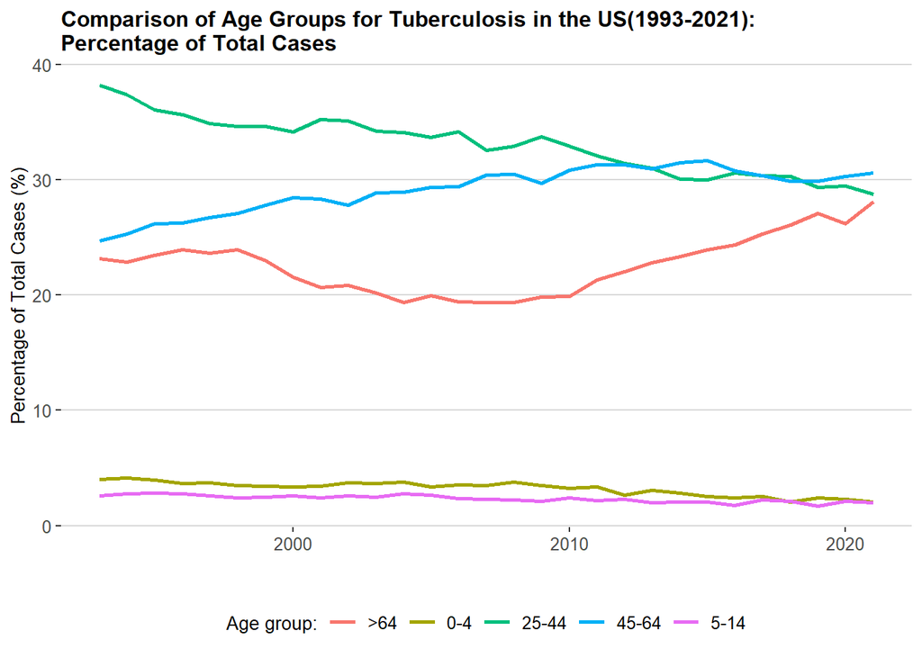

**Observations**

- The majority of infections are caused in the age group greater than 24 years.
- Infections are less prevalent in younger populations (0-14 years).

### Rate comparision by age group

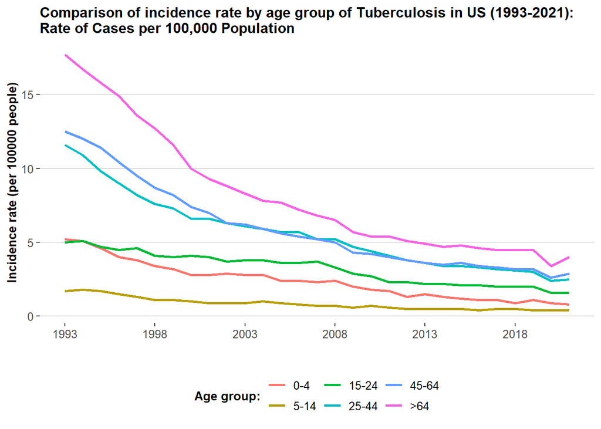

**Observations**

- Incidence rates are higher among adults than among children
- 65 years of age or older had the highest TB incidence rate throughout the years.

**Insights**

BCG Vaccine is only 37% effective against TB in children younger than 5 years, but does not offer protection to adolescents or adults after close exposure. This could be the reason for adult being more affected by TB.

## Race/Ethinicity analysis:

Race/Ethnicity analysis helps to understand the disease susceptibility across different ethnic groups and to identify the vulnerable populations. The data used to carry out this analysis is given in the table below.

```r
# Subset data
df_tb_race <- df_tb_race %>%
  select(Year, Bridged.Race...Ethnicity, Cases, Rate.per.100.000)

# set intuitive names
names(df_tb_race) <- c("year", "races_ethnicity", "cases", "inci_rate_per_100000")

# remove NA
df_tb_race <- na.omit(df_tb_race)

# Replacing "Not applicable" to NA
df_tb_race$inci_rate_per_100000 <- replace(df_tb_race$inci_rate_per_100000, df_tb_race$inci_rate_per_100000 == "Not Applicable", NA)
df_tb_race$inci_rate_per_100000 <- as.numeric(df_tb_race$inci_rate_per_100000)

dt_tb_race <- datatable(df_tb_race)
```

|  | year | races_ethnicity | cases | inci_rate_per_100000 |
| --- | --- | --- | --- | --- |
| 1 | 2021 | American Indian or Alaska Native, Non-Hispanic | 87 |  |
| 2 | 2021 | Asian or Pacific Islander, Non-Hispanic | 2949 |  |
| 3 | 2021 | Black or African American, Non-Hispanic | 1420 |  |
| 4 | 2021 | White, Non-Hispanic | 884 |  |
| 5 | 2021 | Hispanic or Latino | 2410 |  |
| 6 | 2021 | Not Reported | 132 |  |
| 7 | 2020 | American Indian or Alaska Native, Non-Hispanic | 77 | 2.78 |
| 8 | 2020 | Asian or Pacific Islander, Non-Hispanic | 2699 | 12.68 |
| 9 | 2020 | Black or African American, Non-Hispanic | 1413 | 3.24 |
| 10 | 2020 | White, Non-Hispanic | 777 | 0.39 |

[output cut: 164 more lines]

The data for this analysis is visualized through Stacked bar graph and Line graph.

```r
stacked_bar_chart_races <- df_tb_race %>%
  ggplot(aes(year, cases, fill = races_ethnicity)) +
  geom_bar(stat = "identity") +
  theme_hc()  +
  scale_x_continuous(breaks = seq(min(df_tb_race$year), max(df_tb_race$year), 5)) +
  theme(title = element_text(size = 9, face = "bold"),
        legend.text = element_text(size =  7)) +
  labs(title = "Comparison of Number of Cases of Tuberculosis for different Races/Ethinicities in US (1993-2021)",
       y = "Total cases per year",
       x = "",
       fill = "Race/Ethinicity")
```

```r
line_chart_races_rate <- ggplot(df_tb_race, aes(x = year, y = inci_rate_per_100000, color = races_ethnicity)) +
      geom_line(stat = "identity", linewidth = 1) +
      labs(x = "Year", y = "rate per 100000 population") +
      theme_hc() +
      scale_x_continuous(breaks = seq(min(df_tb_race$year), max(df_tb_race$year), 5)) +
      theme(title = element_text(size = 9, face = "bold"),
            legend.text = element_text(size = 7)) +
  labs(title = "Comparison of Incidence rate of Tuberculosis for different Races/Ethinicities in US (1993-2021)",
       y = "Incidence rate (per 100000 people)",
       x = "",
       color = "Race/Ethinicity")
```

### Stacked bar chart for cases

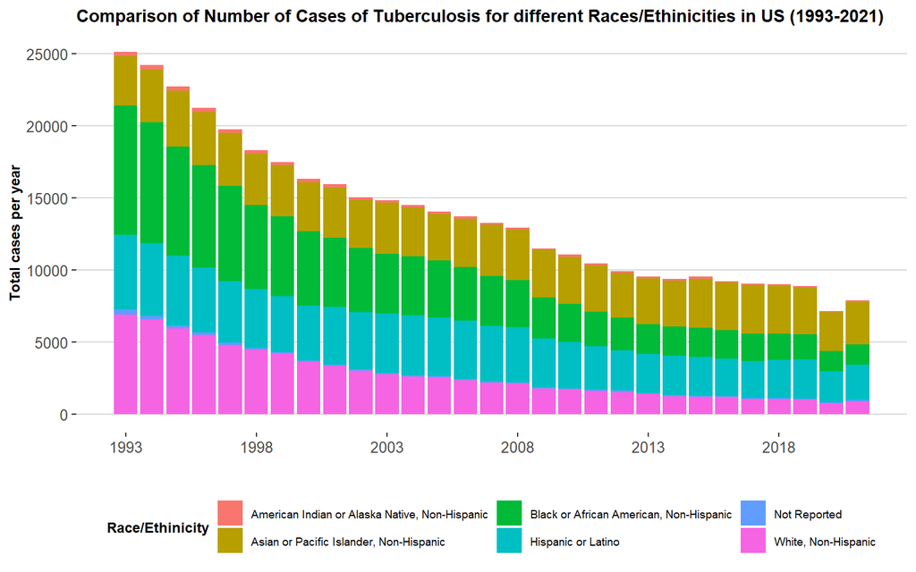

**Observations**

- Majority of the population affected by TB are non-whites.

### line chart for rate

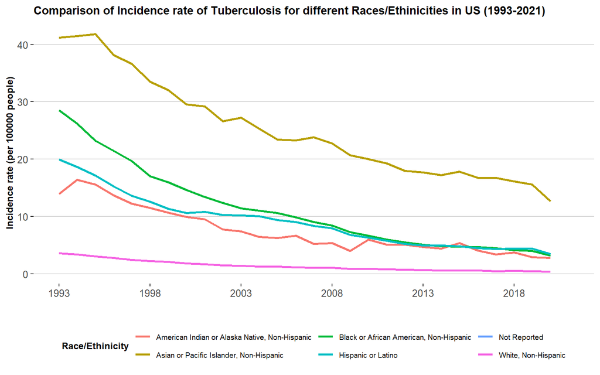

**Observations**

- The incidence rate of Tuberculosis is the maximum in Asian or Pacific Islander population and the least in Whites.
- Asian is the most TB affected population followed by African Americans.

**Insights**

- Socioeconomic factors like literacy, poverty, employment could directly or indirectly increase the risk for TB disease and present barriers to treatment.
- Tuberculosis seems to be a disease of underprivileged as all of the races except Asians that have high incidence rate also has Median Income lower than the national average.
- Also National Assessment of Educational Progress or NAEP for races with high incidence rate except Asians was found to be lower than the national average.

# Drug resistance analysis:

Considering the result for the ethnicity analysis, since TB mostly affects educationally under privileged population, drug resistance could be an emerging problem for Tuberculosis treatment. In order to check this, drug resistance analysis is performed.

For visualizing the drug resistance data for the analysis, the required preporcessing and cleaning steps are performed and then stacked bar chart as well as line chart are made.

```r
# Subset isoniazid resistant data
df_isoniazid_resi <- df_drug_resi %>%
  select(year, total_cases, num_INH, perc_INH, prev_TB_num_INH, prev_TB_perc_INH,
         no_prev_TB_num_INH., no_prev_TB_perc_INH)

# Subset multi drug resistant data
df_mdr_resi <- df_drug_resi %>%
  select(year, total_cases, num_MDR, perc_MDR, prev_TB_num_MDR, prev_TB_perc_MDR,
         no_prev_TB_num_MDR, no_prev_TB_perc_MDR)

df_isoniazid_resi$total_cases <- as.numeric(gsub(",", "",
                                                 df_isoniazid_resi$total_cases))

df_isoniazid_resi$num_INH <- as.numeric(gsub(",", "",
                                             df_isoniazid_resi$num_INH))
df_isoniazid_resi$no_prev_TB_num_INH. <- as.numeric(gsub(",", "",
                                                         df_isoniazid_resi$no_prev_TB_num_INH.))

df_isoniazid_history_cases_longer <- df_isoniazid_resi %>%
  select(year, prev_TB_num_INH, no_prev_TB_num_INH.) %>%
  pivot_longer(!year, names_to = "TB_history", values_to = "number_of_cases")

stacked_bar_chart_drug_resi <- ggplot(df_isoniazid_history_cases_longer, aes(year, number_of_cases, fill = TB_history)) +
  geom_bar(stat = "identity") +
  scale_x_continuous(breaks = seq(min(df_drug_resi$year), max(df_drug_resi$year), 5)) +
  theme_hc() +
  scale_fill_manual(values = c("grey", "gold"), labels = c("No history of TB", "Has history of TB")) +
  labs(x = "",
       y = "Total cases per year",
       fill = "TB history",
       title = "Comparison of Isoniazid resistant cases by Tuberculosis history in US (1993-2021):\nTotal cases throughout years") +
  theme(title = element_text(size = 9, face = "bold"))

line_chart_resi <- df_drug_resi %>%
  select(year, perc_INH, perc_MDR) %>%
  pivot_longer(!year, names_to = "cases_perc", values_to = "values") %>%
  ggplot(aes(year, values, group = cases_perc, color = cases_perc)) +
  geom_line()  +
  theme_hc() +
  scale_x_continuous(breaks = seq(min(df_drug_resi$year), max(df_drug_resi$year), 5)) +
  scale_color_manual(values = c("red", "gold"),
                     labels = c("Isoniazid", "Multi-Drug")) +
  scale_y_continuous(breaks = seq(1, 10, 1)) +
  labs(x = "",
       y = "Percentage(%)",
       color = "Drug resistance",
       title = "Comparison by type of drug resistance of Tuberculosis in US(1993-2021):\nPercentage of total cases") +
  theme(title = element_text(size = 9, face = "bold"))

line_chart_resi_no_prev <- df_drug_resi %>%
  select(year, no_prev_TB_perc_INH, no_prev_TB_perc_MDR) %>%
  pivot_longer(!year, names_to = "cases_perc", values_to = "values") %>%
  ggplot(aes(year, values, group = cases_perc, color = cases_perc)) +
  geom_line() +
  theme_hc() +
  scale_x_continuous(breaks = seq(min(df_drug_resi$year), max(df_drug_resi$year), 5)) +
  scale_color_manual(values = c("red", "gold"),
                     labels = c("Isoniazid", "Multi-Drug")) +
  scale_y_continuous(breaks = seq(1, 10, 1)) +
  labs(x = "",
       y = "Percentage(%)",
       color = "Drug resistance",
       title = "Comparison by type of drug resistance with no previous Tuberculosis history in US(1993-2021):\nPercentage of total cases") +
  theme(title = element_text(size = 9, face = "bold"))
```

## TB history

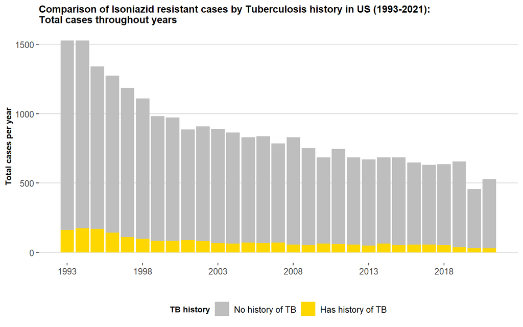

**Observations**

- The drug resistance to isoniazid is much more in cases with no history of TB, which is quite alarming.

## Drug resistance Comparison

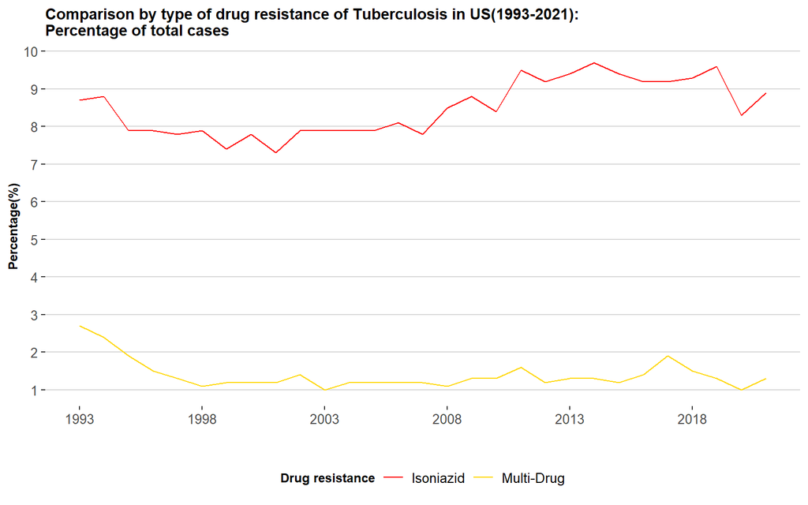

**Observations**

- 10% of all TB cases have drug resistance either to isoniazid or MDR throughout the years.

## Drug resistance Comaprison with No previous TB

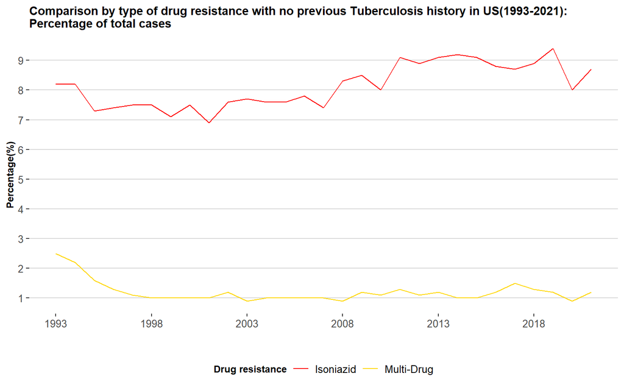

**Observations**

- Almost 10% of all cases with no previous TB history have drug resistance either to isoniazid or MDR throughout the years.

**Insights**

- Drug Resistance in TB is a major concern in the US as 10% of cases with and without prior history of TB infection have developed drug resistance.
- There are also cases of XDR TB caused by an organism that found to be resistant to almost all available treatment options of TB.
- This analysis suggests that there is an urgent need for development of a new vaccine as the situation of drug resistance could get worse very quickly in coming years.

# Discussion

**Cons**

For more in depth report, the following analysis needs to be performed:

- Risk factor analysis to determine what factors make people more susceptible to TB.
- Economic Analysis to understand the economic burden of TB.
- Although this study suggests that TB is a disease of under privileged, a more in depth analysis of occupation is needed.

**Pros**

- The data used in this analysis from CDC is appropriate in getting valuable insights on Tuberculosis in the US.
- The demographic and drug resistance analysis suggests that a more targeted approach is needed to combat TB. Hence, new vaccine development is the way forward.

# Conclusion

From all the insights that we have gathered from this study:

- Low efficacy of BCG vaccine
- Individualized vaccination approach
- Growing drug resistance against the anti-TB drugs

The BCG vaccine is not efficient enough to help us combat the the deadly disease of Tuberculosis. The situation is becoming more alarming with growing drug resistance cases and emergence of XDR drug resistance. Our study suggest that more efficient vaccine is the way forward.

# Literature

https://www.who.int/news-room/fact-sheets/detail/tuberculosis

https://www.thelancet.com/journals/langlo/article

https://www.ncbi.nlm.nih.gov/pmc/articles/PMC5012571/

https://www.ncbi.nlm.nih.gov/pmc/articles/PMC5012571/